# Как собрать свой беспилотник за 1.5 часа

[figure not shown]

Ключевые особенности:

- Можно сделать на недорогом железе
- Можно действительно сможем уложиться в 1.5 часа с минимумом накладных расходов
- Параллельно я буду рассказывать, как это делают другие люди/компании
- Мы говорим об автономном автомобиле
- Мы не говорим об очень надежном и транспорте, который человек в здравом уме выпустит на дорогу
  - Он будет ездить
  - Он будет избегать препятствий
  - Он даже будет по возможности соблюдать ПДД
  - Вы не сможете в нем спокойно пить кофе, по крайней мере не пролив его

Что желательно уже знать:

- Что такое нейронные сети и как их тренируют
- Питон

## Содержание

### Подготовка

1. Язык программирования, среда разработки и рабочее место
2. Библиотеки и инструменты
3. Камеры/лидары/радары?
4. Где найти тачку?
5. Что будем делать?

### Как это работает

1. Из чего состоит беспилотный мозг
2. Control
3. Perception tasks
   1. Обнаружение препятствий
   2. Обнаружение проходимого пути
   3. Обнаружение сигналов
   4. Локализация и одометрия
4. Perception Deep learning tasks
   1. Классификация
   2. Детекция
   3. Детекция 3D
   4. Сегментация
   5. Объектная сегментация
   6. Детекция ключевых точек
   7. Генерация изображения (аугментация ИИ)
   8. Повышение разрешения
   9. Предсказание глубины
   10. End-to-end learning
5. Perception 3D reconstruction
6. Planning

### Как мы это реализуем

1. Control script carla
2. Perception: deep learning
   1. Ищем датасеты
   2. Создаем датасеты
      1. Игры
      2. Симуляторы
         1. Ссылочка на статью с тренировкой
   3. Классифицируем погодные условия (с заделом на светлое будущее)
   4. Аугментируем изображения
      1. Почему без ганов
      2. Как аугментируем
   5. Выбираем сеть семантической разметки
      1. Готовые архитектуры
      2. Датасеты
      3. Ремарочка про объектную разметку с помощью стерео
   6. Выбираем детектор и/или объектную сегментацию
      1. Датасеты, архитектуры и готовые веса
      2. Про датасеты (коко, везде ли он подходит) и нашу задачу
      3. Ремарочка про производительность в торче
3. Perception Deep learning tasks
   1. End-to-end learning
4. Perception 3D reconstruction
   1. Обнаружение препятствий
   2. Обнаружение проходимого пути
   3. Обнаружение сигналов
   4. Локализация и одометрия
5. Фьюзинг
   1. Собираем данные
   2. Выравниваем их по ТС
   3. Закладываем трекинг
   4. Добавляем поведенческий алгоритм
6. Planning

### Давайте тестировать

1. Взаимодействие с модулем контроля

### Что дальше?

1. Следующая игра?
2. Где подвох?

## Подготовка

### Язык и инструметы

[figure not shown]

### Выбор датчиков (небольшой обзор того, что можно купить в интернетах)

[figure not shown]

#### Камеры

##### Визуальный спектр

[figure not shown]

Как применять:

- Распознавание дорожной обстановки (светофоры, полотно, люди, машины)
- Визуальная одометрия
- Стриминг видео
- SFM

| Достоинства | Недостатки |
| --- | --- |
| Огромный выбор различных вариаций на рынке | Данные становятся полезными только после их обработки |
| Доступная цена | Множество параметров при выборе (разрешение, матрицы, аппаратная фунециональность) |
| Огромное количество информации, достаточной для человека |  |
| Вариативность объективов |  |

##### Стерео камеры

[figure not shown]

| Достоинства | Недостатки |
| --- | --- |
| Есть как готовые решения, так и возможности собрать самостоятельно | Вычислительная сложность |
| Большая плотность данных (зависит от разрешения и алгоритма) | Трудности с калибровкой |
| На выходе облако 3D точек и их цвет | Нелинейная ошибка |
| Возможность подстроиться под интересующую зону интересов | Необходимость грамотного подхода к выбору зоны интересов |
|  | Необходимость синхронизации затворов камер |

##### Структурированный свет

[figure not shown]

| Достоинства | Недостатки |
| --- | --- |
| Дешевое решение | Низкая дальность |
| Большая плотность точек реконструкции |  |
| На выходе облако 3D точек и их цвет |  |

##### Ик (ближний, SWIR, тепловизоры)

[figure not shown]

Матрицы камер работают в различных ИК диапозонах (могут включать в том числе и видимый спектр)

| Достоинства | Недостатки |
| --- | --- |
| Работа в условиях низкой освещенности | Диапозон, предоставляющий наиболее подробную информацию о температуре, стоит очень дорого |
| Отлично подходят для распознавания людей и работающей техники | Диапозон, предоставляющий наиболее подробную информацию о температуре, накладывает расходы на установку |

##### ToF

[figure not shown]

| Достоинства | Недостатки |
| --- | --- |
| Небольшой размер | Низкая дальность |
| Точность | Чувствительность к фоновому свету |
| Частота до 160Гц |  |

Характеристики готовых решений: https://rosindustrial.org/3d-camera-survey

##### Лидары

[figure not shown]

Принцип работе заключается в лучевом лазерном сканировании

| Достоинства | Недостатки |
| --- | --- |
| Высокая точность облака точек | Высокая стоимость |
| Простота разработки | Более дешевые модели имеют проблемы с пороговым сигналом переотражения |
| Частота работы 10+ Гц | Ненадежность в сложных условиях эксплуатации |

##### Радары

[figure not shown]

| Достоинства | Недостатки |
| --- | --- |
| Точность определения дистанции | Низкая разрешающая способность |
| Получения данных о скорости объектов | Необходимость фильтрации данных, особенно в условиях эксплуатации среди множество металлических предметов |
| Доступный ценовой диапозон |  |
| Надежность в сложных погодных условиях |  |

#### Сравнение

[output not shown]

Мы остановимся на одной обычной камере:

- Дешево
- Достаточно для человека
- Большое количество открытых данных

### Где найти тачку?

[figure not shown]

### Что будем делать?

[figure not shown]

## Приступим

[figure not shown]

## Как работает беспилотник

### Архитектуры

### Control

### Perception tasks

#### Обнаружение препятствий

#### Обнаружение проходимого пути

#### Локализация и одометрия

### Perception Deep learning tasks

```
Классификация
Детекция
Детекция 3D
Сегментация
Объектная сегментация
Детекция ключевых точек
Генерация изображения (аугментация ИИ)
Повышение разрешения
Предсказание глубины
End-to-end learning
```

### Planning

### ROS

```python
import cv2 as cv      # library for classic computer vision
import numpy as np    # library for working with matrices in python
import matplotlib     # library for visualization
import torch          # library for machine learning
import torchvision    # pretrained models and preprocessing operations
# import open3d as o3d  # library for working with 3d point cloud
import PIL            # library for working with images
```

```python
import glob
import sys
```

```python
sys.path.append('../')
```

import our libraries and utils

[figure not shown]

### *OpenSFM*

```python
from CityScapesUtils import *  # useful stuff for cityscapes-like dataset
```

create input/target transforms for dataset

```python
import torchvision.transforms as T

def torch_unsqueeze(input):
    return input.unsqueeze(0)

input_transform = T.Compose([
    #T.ToPILImage(),  # uncomment for usage with opencv images
#     T.Resize(480, interpolation=PIL.Image.NEAREST),
#     T.CenterCrop((480, 640)),
    T.ToTensor(),
])

def target_transform(type_in, type_out):
    return T.Compose([
        #T.ToPILImage(),  # uncomment for usage with opencv images
    #     T.Resize(480),
#         T.Resize(480, interpolation=PIL.Image.NEAREST),
#         T.CenterCrop((480, 640)),
        CityscapesTransform(type_in, type_out),
        T.ToTensor(),
    ])

def target_in_net_transform(x):
    return x.type(torch.LongTensor)[0]
```

load carla dataset

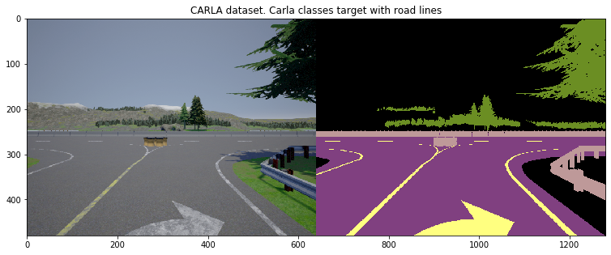

```python
%matplotlib inline
import matplotlib.pyplot as plt

CARLA_dataset_path = '../../datasets/Carla_Sequence_04HIGH/'

CARLA_validation_dataset = torchvision.datasets.Cityscapes(
    CARLA_dataset_path, split='val', mode='fine', target_type='semantic',
    transform=input_transform, target_transform=target_transform('CarlaClasses', 'CarlaClassesWithRoadLines'))

CARLA_val_loader = torch.utils.data.DataLoader(
    CARLA_validation_dataset, batch_size=1)

g, smnt = CARLA_validation_dataset[2]

matplotlib.rcParams['figure.figsize'] = [12.8, 9.6]
plt.title('CARLA dataset. Carla classes target with road lines')
plt.imshow(
    np.hstack((
        (g.numpy().transpose(1, 2, 0)*255).astype(np.uint8),
        decode_cityscapes(smnt[0], mode='CarlaClassesWithRoadLines'))))
plt.show()
```

CarlaClasses

Let's see our sequence as a video

```python
seq_video = cv.VideoWriter('source_data.webm', cv.VideoWriter_fourcc(*'VP80'), 10, (640, 480))
```

```python
import glob

img_pathes = glob.glob(CARLA_dataset_path + 'leftImg8bit/*/*/*')
img_count = len(img_pathes)

for i, img in enumerate(sorted(img_pathes)):
    img = cv.imread(img)
    seq_video.write(img)
    print('{}/{}'.format(i, img_count) , end='\r')

seq_video.release()
```

```
181/182
```

```python
%%HTML
<video width="640" height="480" controls autoplay>
  <source src="source_data.webm" type="video/webm">
</video>
```

[video not shown]

```python
torch.cuda.is_available()
```

```
True
```

Add car detection using ssd pretrained on COCO dataset

```python
ssd_model = torch.hub.load('NVIDIA/DeepLearningExamples:torchhub', 'nvidia_ssd', model_math='fp16').cuda().eval()
```

```
Using cache found in /home/sid1057/.cache/torch/hub/NVIDIA_DeepLearningExamples_torchhub
```

```python
ssd_utils = torch.hub.load('NVIDIA/DeepLearningExamples:torchhub', 'nvidia_ssd_processing_utils')
```

```
Using cache found in /home/sid1057/.cache/torch/hub/NVIDIA_DeepLearningExamples_torchhub
```

```python
classes_to_labels = ssd_utils.get_coco_object_dictionary()
```

```python
%%time
ouput = None

ssd_video = cv.VideoWriter('ssd_example.webm', cv.VideoWriter_fourcc(*'VP80'), 10, (640, 480))

img_pathes = glob.glob(CARLA_dataset_path + 'leftImg8bit/*/*/*')
img_count = len(img_pathes)

for i, img in enumerate(sorted(img_pathes)):
    img = cv.imread(img)
    img = cv.cvtColor(img, cv.COLOR_BGR2RGB)
    tensor = T.ToTensor()(cv.resize(img, (300, 300)))
    tensor = tensor.unsqueeze(0)

    output = ssd_model(tensor.half().cuda())
    try:
        results_per_input = ssd_utils.decode_results(output)
        best_results_per_input = [ssd_utils.pick_best(results, 0.40) for results in results_per_input]

        for image_idx in range(len(best_results_per_input)):
            bboxes, classes, confidences = best_results_per_input[image_idx]
            for idx in range(len(bboxes)):
                left, bot, right, top = bboxes[idx]
                x, y, w, h = [val * 300 for val in [left, bot, right - left, top - bot]]
                x, y, w, h = int(x*2.13), int(y*1.6), int(w*2.13), int(h*1.6)
                img = cv.rectangle(img, (x, y), (x+w, y+h), (0, 0, 255))

                img = cv.putText(
                    img, "{} {:.0f}%".format(classes_to_labels[classes[idx] - 1], confidences[idx]*100),
                    (x,y), cv.FONT_HERSHEY_SIMPLEX, 0.75,(255,255,255),1,cv.LINE_AA)
    except RuntimeError:
        pass

    ssd_video.write(cv.cvtColor(img, cv.COLOR_RGB2BGR))
    print('{}/{}'.format(i, img_count) , end='\r')

ssd_video.release()
```

```
CPU times: user 47.5 s, sys: 1.49 s, total: 49 s
Wall time: 31.8 s
```

```python
%%HTML
<video width="640" height="480" controls autoplay>
  <source src="ssd_example.webm" type="video/webm">
</video>
```

[video not shown]

```python
# faster_rcnn = torch.hub.load('pytorch/vision', 'nvidia_ssd', model_math='fp16').cuda().eval()
faster_rcnn = torchvision.models.detection.fasterrcnn_resnet50_fpn(pretrained=True, min_size=300).cuda().eval()
```

```python
%%time
ouput = None

COCO_INSTANCE_CATEGORY_NAMES = [
    '__background__', 'person', 'bicycle', 'car', 'motorcycle', 'airplane', 'bus',
    'train', 'truck', 'boat', 'traffic light', 'fire hydrant', 'N/A', 'stop sign',
    'parking meter', 'bench', 'bird', 'cat', 'dog', 'horse', 'sheep', 'cow',
    'elephant', 'bear', 'zebra', 'giraffe', 'N/A', 'backpack', 'umbrella', 'N/A', 'N/A',
    'handbag', 'tie', 'suitcase', 'frisbee', 'skis', 'snowboard', 'sports ball',
    'kite', 'baseball bat', 'baseball glove', 'skateboard', 'surfboard', 'tennis racket',
    'bottle', 'N/A', 'wine glass', 'cup', 'fork', 'knife', 'spoon', 'bowl',
    'banana', 'apple', 'sandwich', 'orange', 'broccoli', 'carrot', 'hot dog', 'pizza',
    'donut', 'cake', 'chair', 'couch', 'potted plant', 'bed', 'N/A', 'dining table',
    'N/A', 'N/A', 'toilet', 'N/A', 'tv', 'laptop', 'mouse', 'remote', 'keyboard', 'cell phone',
    'microwave', 'oven', 'toaster', 'sink', 'refrigerator', 'N/A', 'book',
    'clock', 'vase', 'scissors', 'teddy bear', 'hair drier', 'toothbrush'
]

faster_video = cv.VideoWriter('faster_rcnn_example.webm', cv.VideoWriter_fourcc(*'VP80'), 10, (640, 480))

img_pathes = glob.glob(CARLA_dataset_path + 'leftImg8bit/*/*/*')
img_count = len(img_pathes)

for i, img in enumerate(sorted(img_pathes)):
    img = cv.imread(img)
    img = cv.cvtColor(img, cv.COLOR_BGR2RGB)
    tensor = T.ToTensor()(img)
    tensor = tensor.unsqueeze(0)

    pred = faster_rcnn(tensor.cuda())[0]

    boxes = pred['boxes'].cpu().detach().numpy().astype(np.int32)
    labels = pred['labels'].cpu().detach().numpy().astype(np.int32)
    scores = pred['scores'].cpu().detach().numpy()

    for idx in range(len(boxes)):
        box = boxes[idx]
        label = labels[idx]
        score = scores[idx]

        if score < 0.6:
            continue

        x, y, x2, y2 = box
        img = cv.rectangle(img, (x, y), (x2, y2), (0, 0, 255))
        img = cv.putText(
            img, "{} {:.0f}%".format(COCO_INSTANCE_CATEGORY_NAMES[label], score*100),
            (x,y), cv.FONT_HERSHEY_SIMPLEX, 0.75,(255,255,255),1,cv.LINE_AA)

    faster_video.write(cv.cvtColor(img, cv.COLOR_RGB2BGR))
    print('{}/{}'.format(i, img_count) , end='\r')

faster_video.release()
```

```
CPU times: user 36.9 s, sys: 3.53 s, total: 40.4 s
Wall time: 30.1 s
```

```python
%%HTML
<video width="640" height="480" controls autoplay>
  <source src="faster_rcnn_example.webm" type="video/webm">
</video>
```

[video not shown]

[figure not shown]

Взято с matworks https://www.mathworks.com/help/deeplearning/ug/pretrained-convolutional-neural-networks.html

[figure not shown]

Кто ещё делает нечто подобное?

- comma.ai
- sendtex

## Время тестов

### Взаимодействие с модулем контроля

## Что дальше?

### Следующая игра?

[figure not shown]

Out Run: За наименьшее время добраться из пункта А в пункт Б не попав в аварию

[figure not shown]

Chase HQ: Протаранить машину преступника, которая соответствует написанной сегодня нами

[figure not shown]

F1: пройти закрытый от других участников движения маршрут быстрее соперников

[figure not shown]

Colin McRae 2.0: Пройти маршрут по открытой местности быстрее соперников

[figure not shown]

NFS Most Wanted (2003): Пройти городской маршрут быстрее соперников, при условии ухода от погони

### Где подвох?

Хорошие условия эксплуатации

99.(9)%

Аппаратная часть

Минимальное количество датчиков (упрощенный фьюзинг)

Примитивный модуль планирования

Модуль контроля из коробки

# Спасибо за внимание!

- **email**: ivanov.dale@gmail.com (`topic: self-driving`)
- **github**: sid1057
- **linkedin**: ivan-deylid

Ссылка на код, презентацию, материалы и продолжение тутора: [sid1057.github.io/self-driving](https://sid1057.github.io/self-driving/)